# Ch7 R Graphics

## Date, Time

as.POSIXlt %d (날짜, 01~31), %m (달, 01~12), %Y (4자리로 표시된 연도) %H (시간, 00~23), %M (분, 00~59), %S (초, 00~59)

```r
class(Pconsump$Date)
```

```
## [1] "factor"
```

```r
class(Pconsump$Time)
```

```
## [1] "factor"
```

```r
Pconsump$newDate <- as.POSIXlt(Pconsump$Date,format="%d/%m/%Y")
Pconsump$newTime <- as.POSIXlt(Pconsump$Time,format="%H:%M:%S")
Pconsump$year <- format(Pconsump$newDate,"%Y")
```

## Timeseries plot

geom = “line”

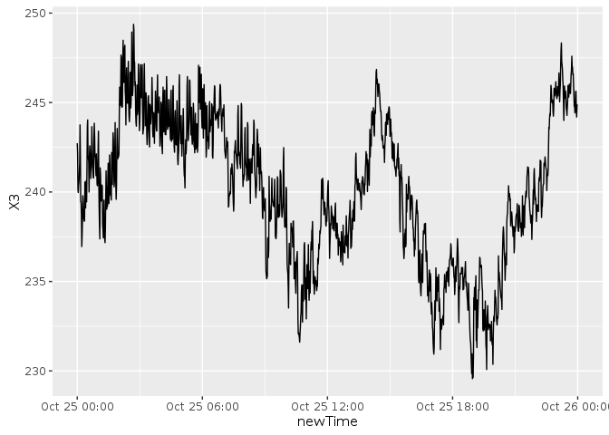

```r
Pconsump.2006.12.17 <- Pconsump[Pconsump$Date == "17/12/2006",]
qplot(newTime, X3, data = Pconsump.2006.12.17, geom = "line")
```

color와 linetype 옵션을 이용하여 범주별로 다른 선으로 표시

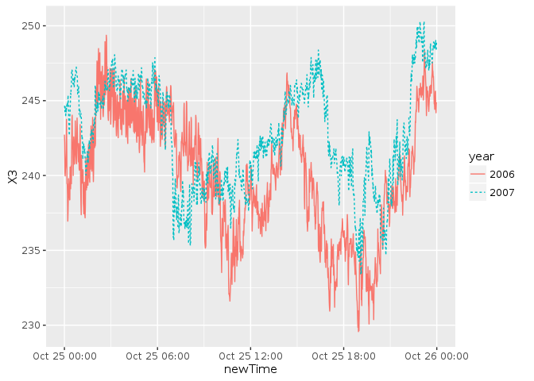

```r
Pconsump.12.17<- Pconsump[(Pconsump$Date == "17/12/2006" |Pconsump$Date == "17/12/2007"), ]
qplot(newTime, X3, data = Pconsump.12.17, color = year, geom = "line", linetype = year)
```

facets = A ~.

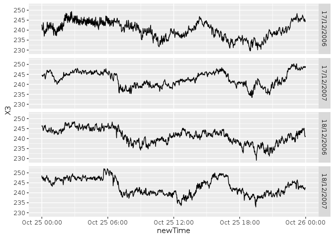

```r
qplot(newTime, X3, data = Pconsump, facets = Date~., geom = "line")
```

## ggplot - aesthetic mapping

ggplot : dataframe aes()

- x
- y
- color
- shape
- size

```r
plot.basic <- ggplot(tipping, aes(x = totbill,
         y = tip,
         color = sex,
         shape = sex,
         size = tiprate))
```

Scatterplot : layer(geom = “point”) geom_point()

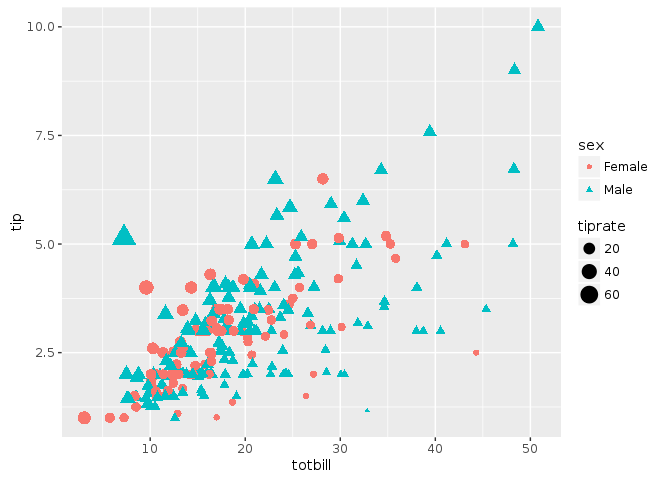

```r
# plot.basic + layer(geom = "point")
# Error: Attempted to create layer with no stat.
plot.basic + geom_point()
```

geom : geom_이름()의형태로이용

- abline : 절편과기울기를이용하여그리는직선
- area : 영역그림
- bar : 막대그림(Y축에지정된변수를이용)
- boxplot : 상자그림
- density : smoothdensity
- histogram : 히스토그램
- hline/vline : 수평직선/수직직선
- jitter : 점흐트려그리기
- line : x값순서로점연결하여그리는직선
- smooth : Smoothline

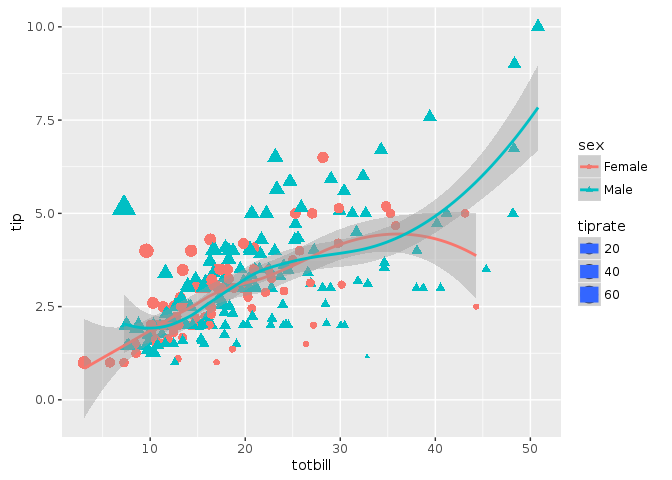

```r
plot.basic + geom_point() + geom_smooth(aes(group = sex))
```

## stst : stat_이름( )의 형태로 이용

- bin : 범주화자료로만들기
- boxplot : 상자그림을위한통계량계산
- contour : 3차원등고선도를위한자료생성
- density : 1차원밀도함수계산
- density_2d : 2차원밀도함수계산
- identity : 통계량을계산하지않고원자료를그대로이용
- qqQQ-plot : 을위한통계량계산
- quantile : 분위수계산
- step : 계단함수형태의그림을위한값계산
- summary : 같은x값에대하여y의통계량을계산

### 다양한 stat을 이용한 그래프

산점도에 통계량을 이용한 점 찍기

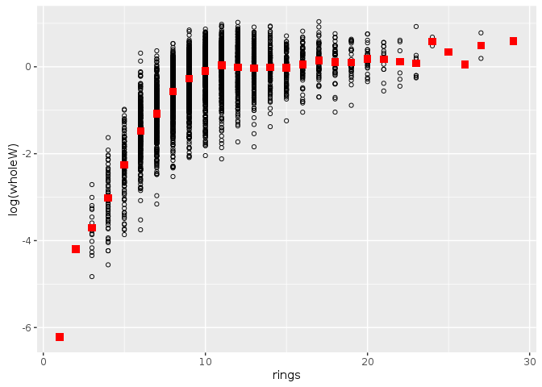

```r
plot.stat <- ggplot(abalone, aes(x=rings,y=log(wholeW)))
plot.stat + geom_point(shape=1) +
 stat_summary(size=3, shape=15, color="red",
        fun.y="mean", geom = "point")
```

fun.data = “mean_cl_normal”

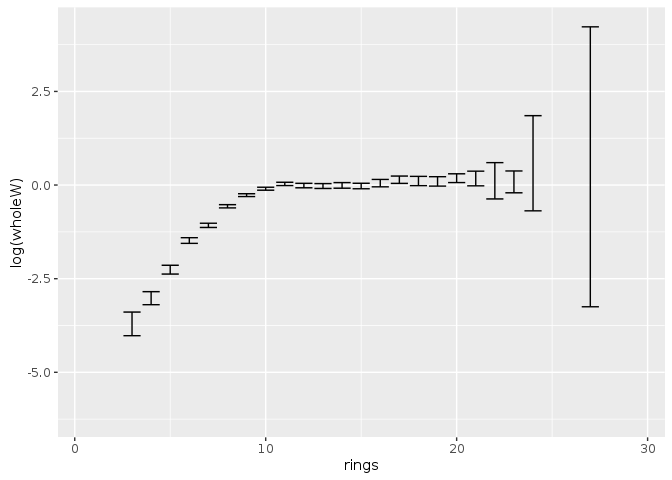

```r
plot.stat + stat_summary(fun.data = "mean_cl_normal", geom="errorbar")
```

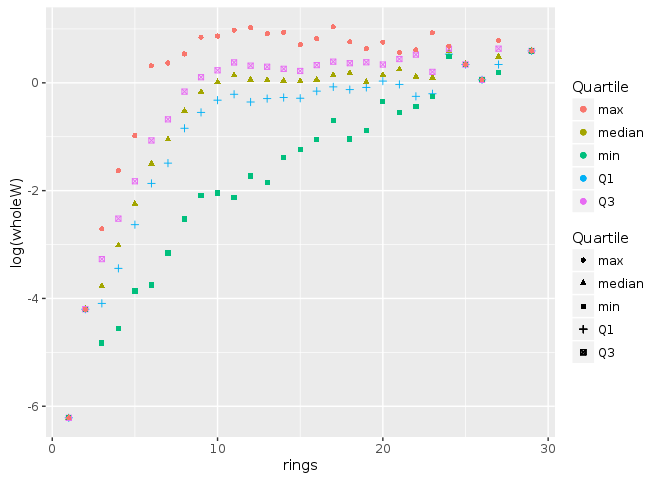

```r
q1 <- function(x) quantile(x, p=0.25)
q3 <- function(x) quantile(x, p=0.75)

plot.stat +
 stat_summary(aes(color="Q1",shape="Q1"), fun.y=q1,geom="point") +
 stat_summary(aes(color="median ",shape="median "), fun.y=median,geom="point") +
 stat_summary(aes(color="Q3",shape="Q3"), fun.y=q3,geom="point") +
 stat_summary(aes(color="min ",shape="min "), fun.y=min,geom="point") +
 stat_summary(aes(color="max",shape="max"), fun.y=max,geom="point") +
 scale_color_hue("Quartile ")+scale_shape("Quartile")
```

stat_bin, geom

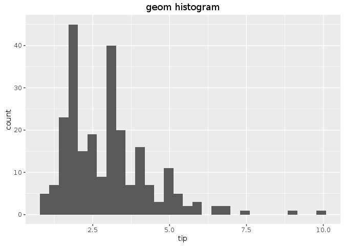

```r
plot.1D <- ggplot(tipping, aes(x=tip))
plot.1D + geom_histogram() + ggtitle("geom histogram")
```

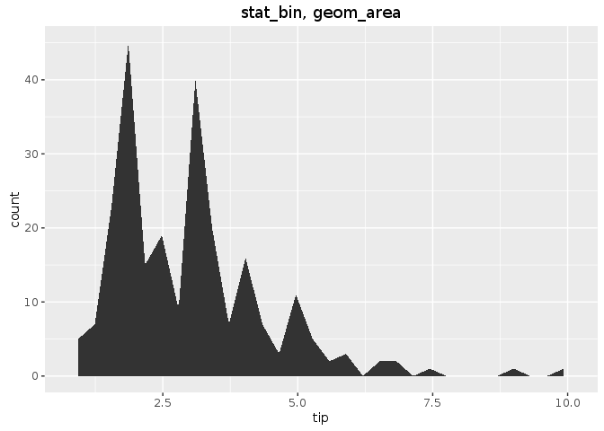

```r
plot.1D + stat_bin(geom = "area") + ggtitle("stat_bin, geom_area")
```

- geom = “point”, geom=“line”

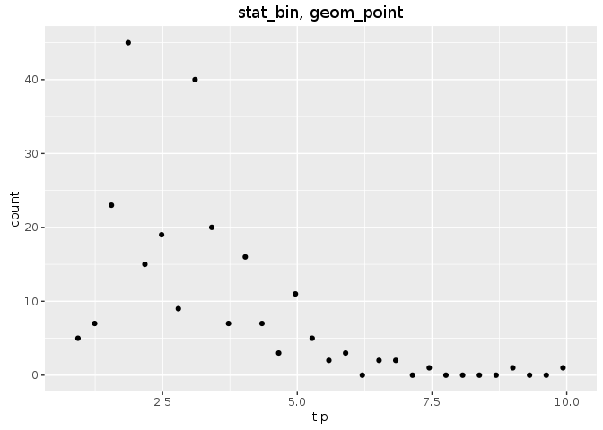

```r
plot.1D + stat_bin(geom = "point") + ggtitle("stat_bin, geom_point")
```

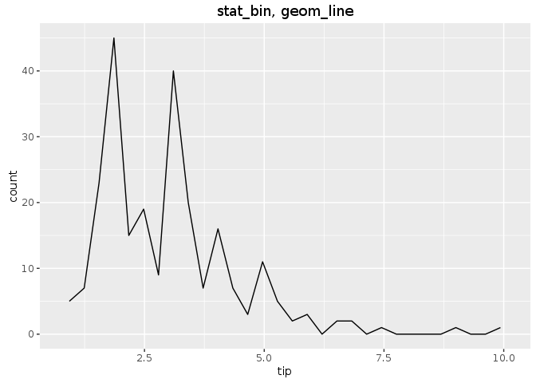

```r
plot.1D + stat_bin(geom = "line") + ggtitle("stat_bin, geom_line")
```

## Position adjustment

- dodge : 겹쳐지는 부분을 옆으로 나란히 정렬하는 방법
- fill : 전체영역을 칠하기
- identity : 그대로 나타내기
- jitter : 겹쳐진 점을 흐트려서 나타내기
- stack : 겹쳐진 부분을 위에 쌓는 형태로 그리기

position = “stack”  
position = “dodge”  
theme(legend.position = “none”) 그림에서 범례를 제외시키기 위한옵션

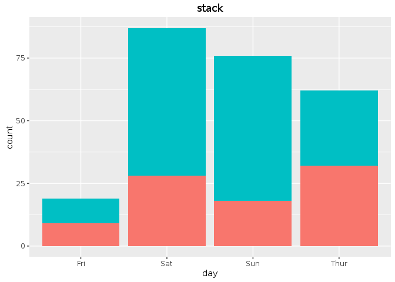

```r
plot.pos <- ggplot(tipping,aes(x = day, fill = sex, shape = sex))
plot.pos + geom_bar(position = "stack") + ggtitle("stack") + theme(legend.position="none")
```

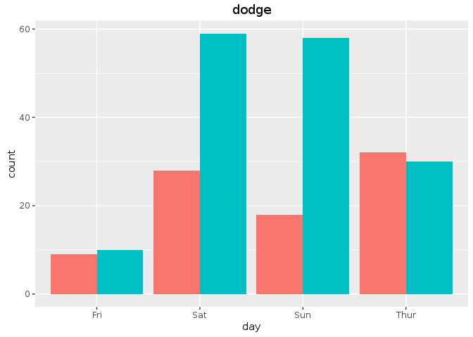

```r
plot.pos+ geom_bar(position = "dodge") + ggtitle("dodge") + theme(legend.position="none ")
```

- position = “fill”
- position = “jitter”

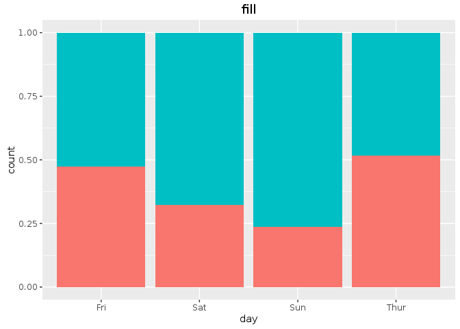

```r
plot.pos + geom_bar(position  = "fill") + ggtitle("fill") + theme(legend.position="none ")
```

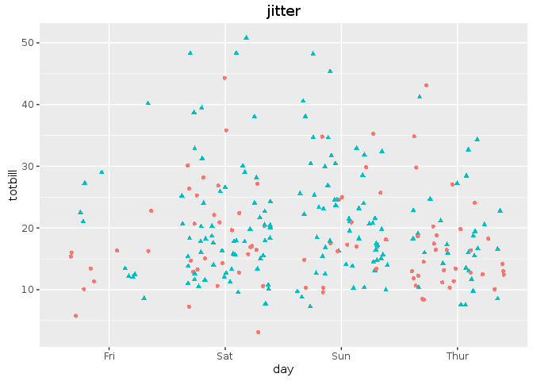

```r
plot.pos + geom_point(aes(y=totbill,color=sex,shape=sex),position="jitter") + ggtitle("jitter") + theme(legend.position="none  ")
```

*position = “identity” alpha

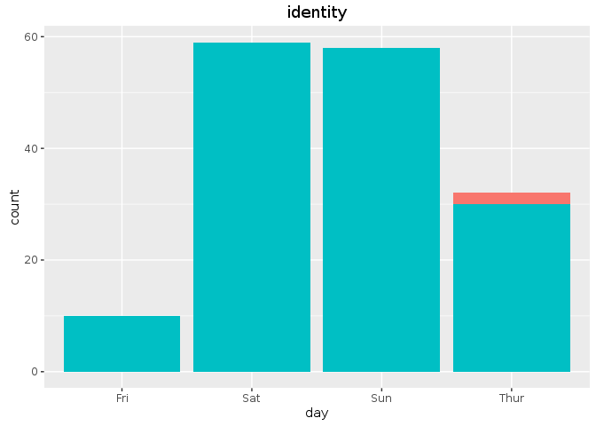

```r
plot.pos <- ggplot(tipping,aes(x   = day  , fill = sex, shape = sex))
plot.pos + geom_bar(position  = "identity") + ggtitle("identity") + theme(legend.position="none ")
```

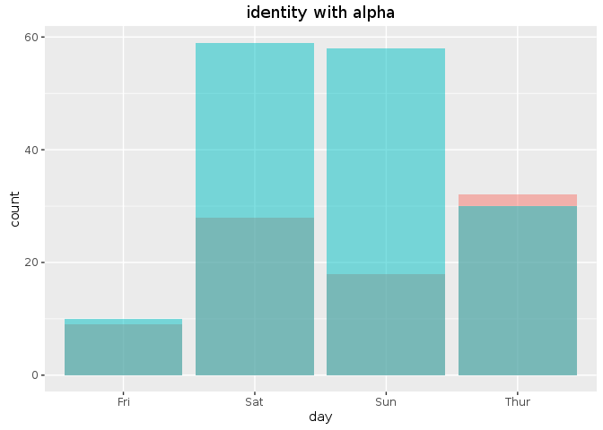

```r
plot.pos + geom_bar(position  = "identity", alpha  = I(0.5)) + ggtitle("identity with alpha") + theme(legend.position="none ")
```

## Scale

shape, size, color scale_color_hue

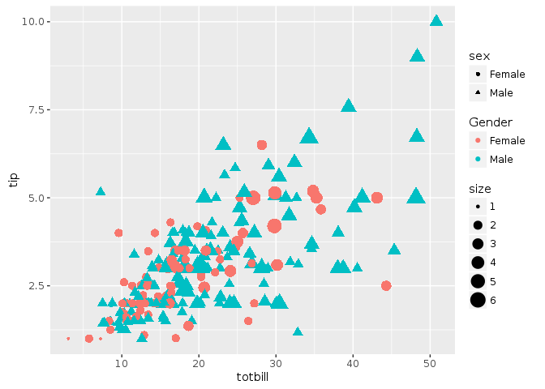

```r
plot.scale1  <- ggplot(tipping,  aes(x=totbill,  y = tip, color = sex, shape = sex, size  = size)) + geom_point()
plot.scale1  + scale_color_hue("Gender", labels = c("Female", "Male"))
```

Scale_color_brewer

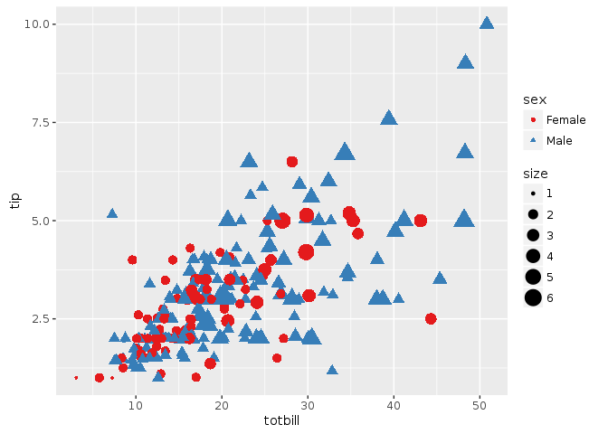

```r
 plot.scale1 + scale_color_brewer(palette="Set1")
```

- scale_x_continuous : x축에 대한 옵션을 제시하는 함수
- breaks = c(20,40) : 20과 40에 눈금을 표시
- scale_y_continuous : y축에 대한 옵션을 제시하는 함수

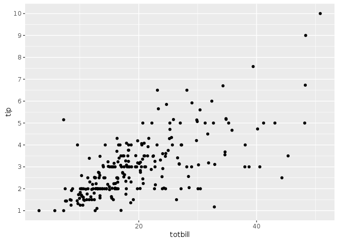

```r
plot.scale2  <- ggplot(tipping,aes(x=totbill,y=tip)) + geom_point()
plot.scale2  + scale_x_continuous(breaks=c(20,40)) + scale_y_continuous(breaks=1:10)
```

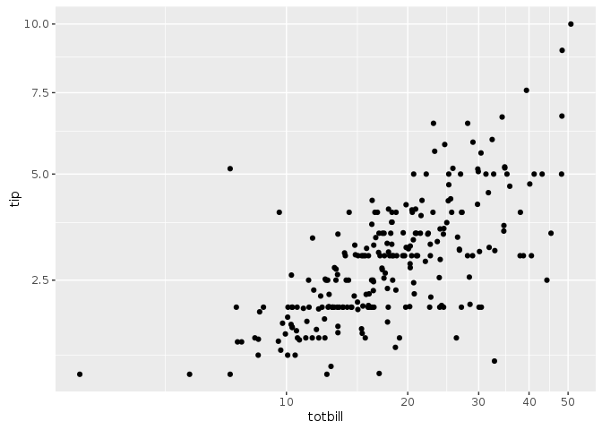

```r
#plot.scale2 + coord_trans(xtrans="log10",ytrans="sqrt")
# Error: `xtrans` arguments is deprecated; please use `x` instead.
plot.scale2 + coord_trans(x="log10",y="sqrt")
```

## Faceting

- facet_grid(A~B) : 변수 A의 범주를 행으로, 변수 B의 범주를 열로 하여 행렬형태로 그림을 그리는 방법
- margins=TRUE : 각 행, 열의 마지막에 주변분포의 그림을 그려줌

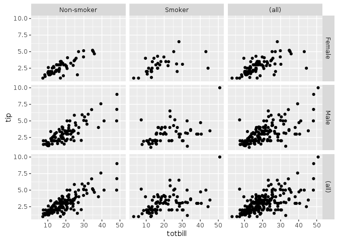

```r
plot.facet <- ggplot(tipping,aes(x = totbill, y = tip)) + geom_point()
plot.facet +  facet_grid(sex ~ smoker , margins  = TRUE)
```

facet_wrap(~A) : 하나의 범주형 변수 A를 이용하는 방법으로 ncol, nrow 옵션을 이용하여 그림 행렬의 모양을 지정

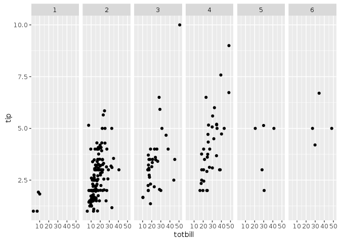

```r
plot.facet + facet_wrap(~ size, ncol = 6)
```

cut_interval, cut_number 함수를 이용하여 연속변수를 범주화

- cut_interval : 자료 값의 범위를 일정하게 하여 n개의 그룹으로 나누어 주는 함수
- cut_number : 각 그룹의 자료수가 같아지도록 n개의 그룹으로 나누어주는 함수

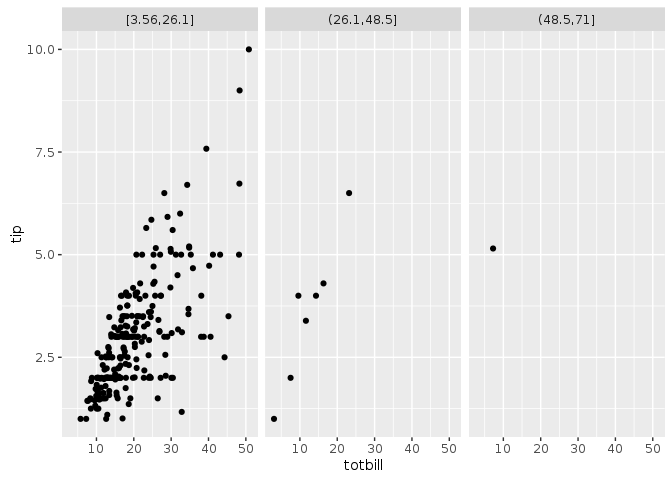

```r
tipping$tipgroup1 <-  cut_interval(tipping$tiprate,n=3)
tipping$tipgroup2 <-  cut_number(tipping$tiprate,n=3)
plot.newfacet <- ggplot(tipping,aes(x=totbill,y=tip)) + geom_point()
plot.newfacet + facet_wrap(~tipgroup1)
```

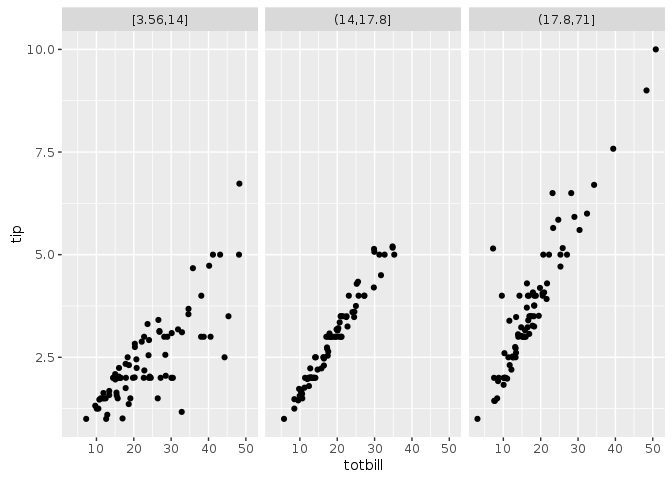

```r
plot.newfacet + facet_wrap(~tipgroup2)
```

## Theme

보고서 작성을 위해 그림을 다듬는 데에 필요한 옵션들

- xlab/ylab : x축/y축 이름을 지정
- ggtitle : 그림의 제목을 지정

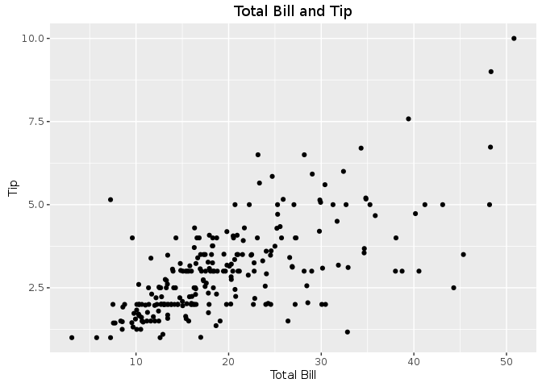

```r
plot.theme <- ggplot(tipping, aes(x = totbill, y = tip))
plot.theme + geom_point() + xlab("Total Bill") + ylab("Tip") + ggtitle("Total Bill and Tip")
```

Theme 함수를 이용하여 그림의 전반적인 사항들 지정

- plot.title : 그림 제목에 관한 옵션 지정

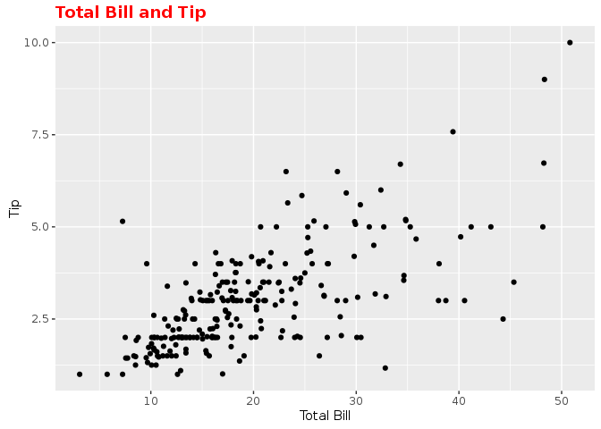

```r
plot.theme + geom_point() + xlab("Total Bill") + ylab("Tip") + ggtitle("Total Bill and Tip") + theme(plot.title = element_text(color = " red", face = "bold", hjust = 0))
```

last_plot : 마지막으로 그린 그림을 불러오는 함수 theme_bw : 배경색을 흰색으로 변경하는 함수 panel.grid.minor/panel.grid.major : 격자선에 관한 옵 panel.border : 그림 테두리에 관한 옵션 axis.line : x, y축의 선에 관한 옵션

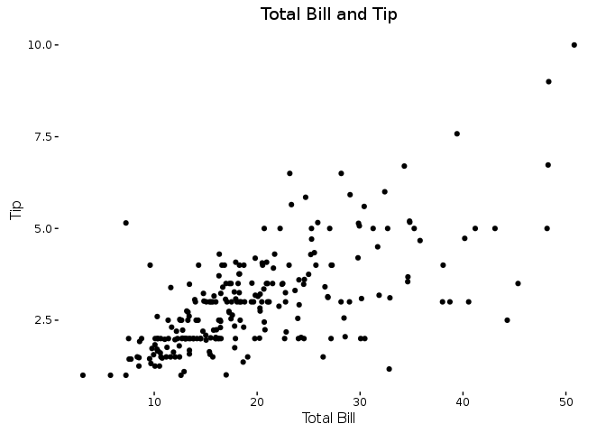

```r
last_plot()+theme_bw()+ theme(panel.grid.major=element_blank(),
                              panel.grid.minor=element_blank(),
                              panel.border=element_blank(),
                              axis.line  = element_line())
```

legend.position = “none” : 범례를 생략하기 위한 옵션

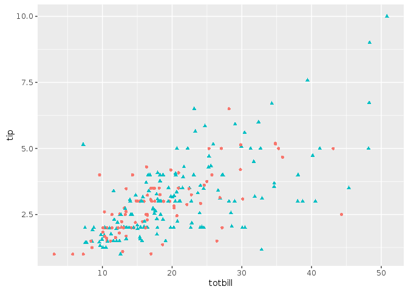

```r
plot.theme  +
    geom_point(aes(color = sex, shape = sex))  +
    theme(legend.position = "none ")
```

geom_text : 그림에 문자를 삽입하기 위한 함수 expression : 수식을 표현하기 위한 함수

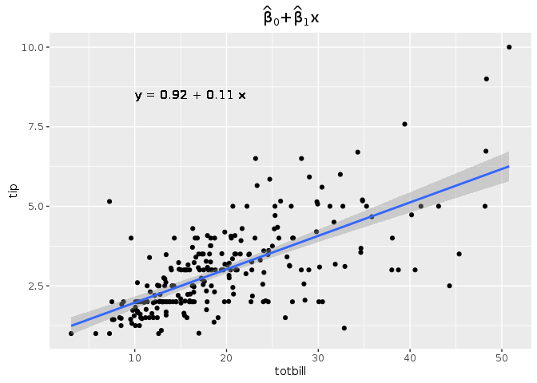

```r
lm.result <- lm(tip~totbill,data = tipping)
ab <- round(coef(lm.result),2)
ggplot(tipping,aes(x=totbill,y=tip))+
          geom_point()+
          geom_smooth(method="lm")+
          geom_text(data  = NULL,x=10,y=8.5,
            label=paste("y =",ab[1],"+",ab[2],"x"), hjust=0)  +
          ggtitle(expression(paste(hat(beta)[0],"+",hat(beta)[1],"x")))
```

ggsave

- R 세션에서 활성화 되어 있는 R Graphics Device에 그려져 있는 그림을 저장해주는 함수
- 파일 이름의 확장자에 맞는 형태의 그림으로 저장
- MS 오피스나 아래한글, 혹은 웹 문서를 위해서는 png 파일을 이용

```r
ggsave("sample-plot.png")
```